# lab05

Sujit Dhanuka

14 April 2018

# (a) Find the mean, median and range for Philip and Matthews

# So, who is more consistent?

# Central Tendency

mean = 19.8 range is between 0 to 35 Median is 20

```r
factory_work <- matrix(data = c(15, 21, 20, 20, 20, 30, 25, 12, 35, 0),
                       nrow = 2, ncol = 5, byrow = TRUE)
rownames(factory_work) = c('Philip', 'Mathew')
colnames(factory_work)  = c('Mon', 'Tue', 'Wed', 'Thur', 'Fri')

factory_work
```

```
##        Mon Tue Wed Thur Fri
## Philip  15  21  20   20  20
## Mathew  30  25  12   35   0
```

```r
# Create the function.
getmode <- function(v) {
   uniqv <- unique(v)
   uniqv[which.max(tabulate(match(v, uniqv)))]
}

my_median <- function(x){
  sort(x)
  n = length(x)
  med_point <- (n+1)/2
      if(n %% 2 ==0){
        absn = abs(med_point)
        absn1 = n+1
        med <- (x[absn] +x[absn1])/2
    }else{
      med <- x[med_point]
    }
  return (med)

}

my_sd <- function(x){
  x_bar = mean(x)
  n = length(x)
  x2 = 0
  for( i in x ){
    x2 = x2+ (i-x_bar)^2
  }
  sd = sqrt(x2/(n-1))
  return(sd)
}


summ <- matrix()
print(summ)
```

```
##      [,1]
## [1,]   NA
```

```r
print("Details for Philip")
```

```
## [1] "Details for Philip"
```

```r
mean(factory_work[1,])
```

```
## [1] 19.2
```

```r
median(factory_work[1,])
```

```
## [1] 20
```

```r
print(my_median(factory_work[1,]))
```

```
## Wed
##  20
```

```r
getmode(factory_work[1,])
```

```
## [1] 20
```

```r
max(factory_work[1,]) - min((factory_work[1,]))
```

```
## [1] 6
```

```r
sd(factory_work[1,])
```

```
## [1] 2.387467
```

```r
print(my_sd(factory_work[1,]))
```

```
## [1] 2.387467
```

```r
print("Details for Mathew")
```

```
## [1] "Details for Mathew"
```

```r
mean(factory_work[2,])
```

```
## [1] 20.4
```

```r
max(factory_work[2,]) - min((factory_work[2,]))
```

```
## [1] 35
```

```r
median(factory_work[2,])
```

```
## [1] 25
```

```r
getmode(factory_work[2,])
```

```
## [1] 30
```

```r
print(sd(factory_work[2,]))
```

```
## [1] 14.25833
```

```r
print(my_sd(factory_work[2,]))
```

```
## [1] 14.25833
```

```r
#
# rownames(summ) <- c('Philip', 'Mathew')
# colnames(summ) <- c('mean', 'median', 'mode', 'Range', 'S.D.')


print(summ)
```

```
##      [,1]
## [1,]   NA
```

```r
t(factory_work)
```

```
##      Philip Mathew
## Mon      15     30
## Tue      21     25
## Wed      20     12
## Thur     20     35
## Fri      20      0
```

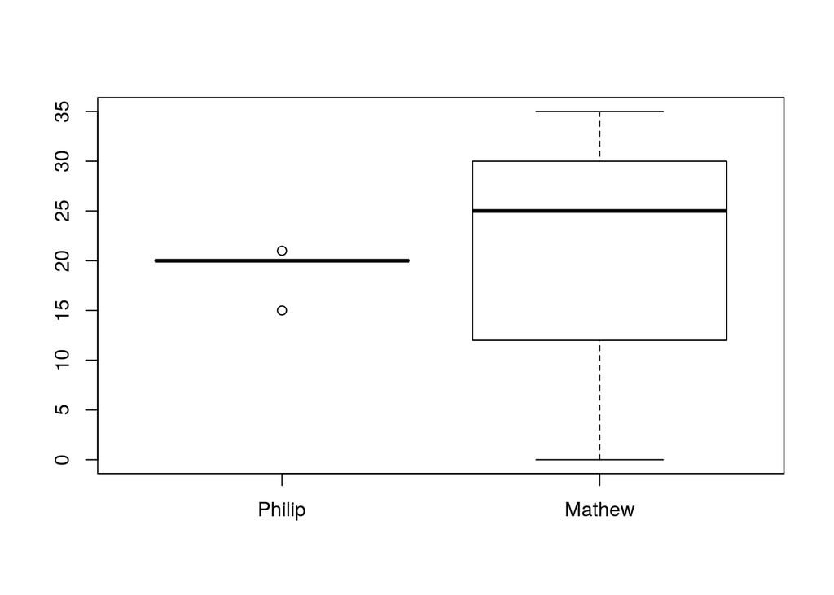

```r
boxplot(t(factory_work))
```

#### 2. Following are Kohli’s scores in 4 matches played between India and Australia, match 5 being the latest one played in a five match series.

# 1 | 65

# 2 | 72

# 3 | 58

# 4 | 77

# - (a) What are his median and mean scores for the first four matches played?

# - (b) If he scores 70 in his fifth match, does his series mean score increase or decrease w.r.t. score obtained for first four matches. Find his new mean score.

# - (c) Which has increased most, his mean score or his median score (w.r.t first five matches)?

```r
kohli_scores <- c(65, 72, 58, 77)
#colnames(kohli_scores) <- c('1','2','3','4')

print(paste0("mean:   ", mean(kohli_scores)))
```

```
## [1] "mean:   68"
```

```r
print(paste0("median :",median(kohli_scores)))
```

```
## [1] "median :68.5"
```

```r
kohli_scores = c(kohli_scores, 70)

print(paste0("New mean:   ", mean(kohli_scores)))
```

```
## [1] "New mean:   68.4"
```

```r
print(paste0("New median :",median(kohli_scores)))
```

```
## [1] "New median :70"
```

## 3. Find the mode for 8,6,2,4,6,8,10,8

###### YOUR SOLUTION HERE

```r
var1 <- c(8,6,2,4,6,8,10,8)
var_table  <- table(var1)
# getmode <- function(v) {
#   return(names(sort(v, decreasing = T))[1])
# }

m = mean(var1)
m1 = median((var1))
mode = 3* m1 - 2*m
print(mode)
```

```
## [1] 8
```

```r
names(sort(var_table, decreasing = T))[1]
```

```
## [1] "8"
```

```r
print(paste0("Mode is :", getmode(var_table)))
```

```
## [1] "Mode is :1"
```

#### 4. Analyze the performance of your class in the first ROTe taken at INSOFE

# - (a) How is the spread of the scores?

# - (b) Draw a histogram to visualize the data distribution.

# - (c) Find the 25th percentile, 50th percentile and 75th percentile for this data.

# - (d) Find outliers, if any. Do a boxplot to visualize the same.

# Scores: 11, 7.5, 8.5, 10, 10, 10.5, 5.5, 10, 9, 9.5, 5.25, 8, 6.5, 10.5, 8.75, 0, 6, 6, 6.75, 8.75, 0, 9.5, 7.5, 8.5, 7

# (a) How is the spread of the scores?

### (b) Draw a histogram to visualize the data distribution.

### (c) Find the 25th percentile, 50th percentile and 75 percentile for this data.

### (d) Find outliers, if any. Do a boxplot to visualize the same.

```r
rote_scores <- c(11, 7.5, 8.5, 10, 10, 10.5, 5.5, 10, 9, 9.5, 5.25, 8, 6.5, 10.5, 8.75, 0, 6, 6, 6.75, 8.75, 0, 9.5, 7.5, 8.5, 7)

#a
rote_table = sort(rote_scores)
rote_table
```

```
##  [1]  0.00  0.00  5.25  5.50  6.00  6.00  6.50  6.75  7.00  7.50  7.50
## [12]  8.00  8.50  8.50  8.75  8.75  9.00  9.50  9.50 10.00 10.00 10.00
## [23] 10.50 10.50 11.00
```

```r
n = length(rote_table)

names(sort(rote_table, decreasing = F))[(n+1)/4]
```

[output not shown]

```r
q1 = quantile(rote_scores)
q1
```

```
##   0%  25%  50%  75% 100%
##  0.0  6.5  8.5  9.5 11.0
```

```r
median(rote_scores)
```

```
## [1] 8.5
```

```r
max(rote_scores) - min(rote_scores)
```

```
## [1] 11
```

```r
print(my_sd(rote_scores))
```

```
## [1] 2.829458
```

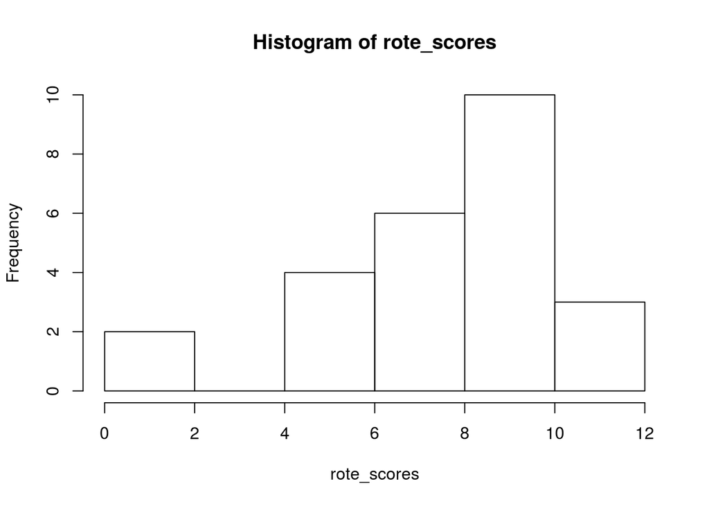

```r
hist(rote_scores)
```

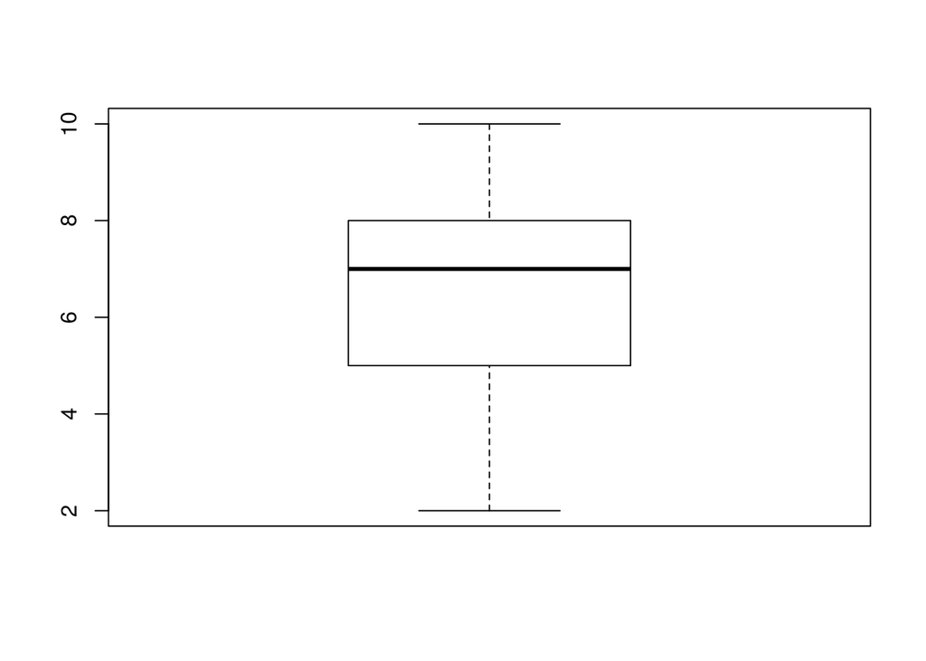

```r
boxplot(var1)
```

```r
#type(1)
whisker1 = q1[2] -(1.5 *IQR(rote_scores))
whisker2 = q1[4] +  (1.5 + IQR(rote_scores))

print(paste0("outliers are below :" , whisker1, "and above : ", whisker2))
```

```
## [1] "outliers are below :2and above : 14"
```